# HIV testing

## Intertest interval

As documented in section @ref(decisions), We will model the intertest interval as an **interval process**, estimated as twice the reported time since the last HIV test. We will use the median as the summary statistic (see section @ref(hivtesting)).

We use data from the WHPP reweighted to the demographics of HIV-negative/undiagnosed men in Washington to estimate this parameter. Additionally, because patterns of testing are different with PrEP use, which the model will reflect, we use data from men who did not report use of PrEP in the past 12 months to estimate testing among men not on PrEP. While it is possible that men who were on PrEP at the time of the survey were more frequent testers than the average MSM before going on PrEP, for now we will assume that the testing patterns of men not on PrEP represents testing in the absence of PrEP for all men, though we will consider exploring ways to account for the pre-PrEP testing patterns of PrEP users in the future (see section @ref(future_explore)).

Exploratory analyses indicate that the intertest interval varies by age (section @ref(explore_heterogeneity)). To capture this, we will fit a regression model to estimate the intertest interval as a function of centered age and centered age squared, and we will use this in the epidemic model to predict the intertest interval as a function of age.[^1] In the model, we will use the mean age in the WHPP sample to calculate centered age and centered age squared so these variables are defined in a manner consistent with the data the model was fitted to. In the plot below, the blue line is the loess smooth on the observed data, and the red line is the prediction from the generalized linear model.

```
##
## Call:
## svyglm(formula = median_iti ~ age_centered + age_cent_sq, design = subset(sample_rake_neg,
##     p12noprep_ego %in% "No PrEP"))
##
## Survey design:
## subset(sample_rake_neg, p12noprep_ego %in% "No PrEP")
##
## Coefficients:
##               Estimate Std. Error t value Pr(>|t|)
## (Intercept)  415.79606   13.56507  30.652  < 2e-16 ***
## age_centered   5.46732    0.55469   9.857  < 2e-16 ***
## age_cent_sq   -0.31862    0.05698  -5.592 3.16e-08 ***
## ---
## Signif. codes:  0 '***' 0.001 '**' 0.01 '*' 0.05 '.' 0.1 ' ' 1
##
## (Dispersion parameter for gaussian family taken to be 29452.2)
##
## Number of Fisher Scoring iterations: 2
```

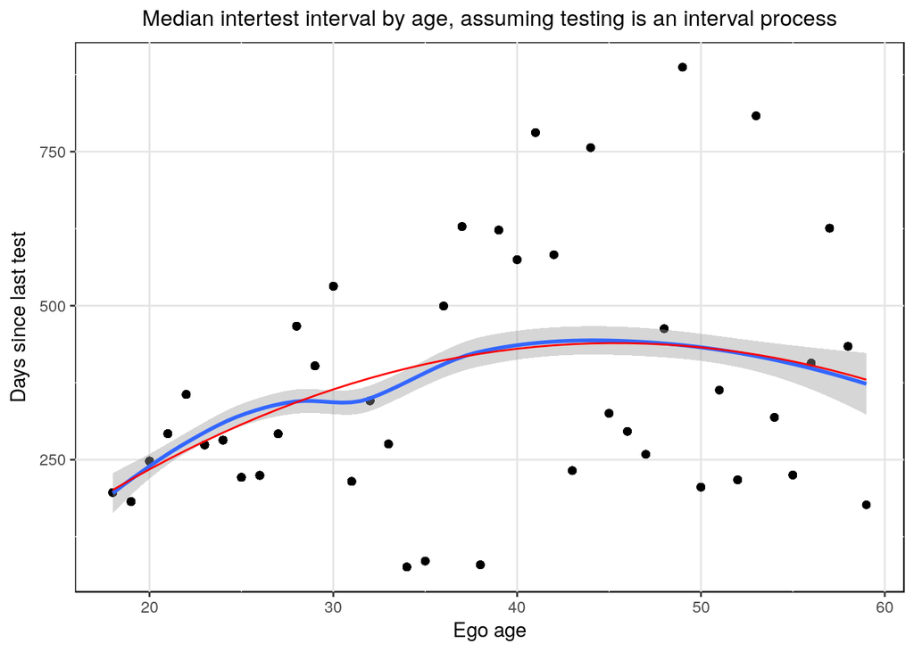

[^1]: Note that, by fitting to centered age squared, the predicted interval will start to come down at higher ages. This does not appear to be very strong by the maximum modeled age of 59, but models with wider age ranges or different data might lead to shorter intervals for older men, which may not reflect reality.